# PlotMicrobiome analysis with AI report

## PlotMicrobiome analysis report with AI assistance

The analysis of microbiome data was performed with PlotMicrobiome (https://github.com/ssun6/plotmicrobiome).

The interpretation of the data was generated with AI models gemma3.

AI can make mistakes, please review all interpretations and conclusions critically before drawing scientific inferences.

### PCoA analysis by rural_urban_status

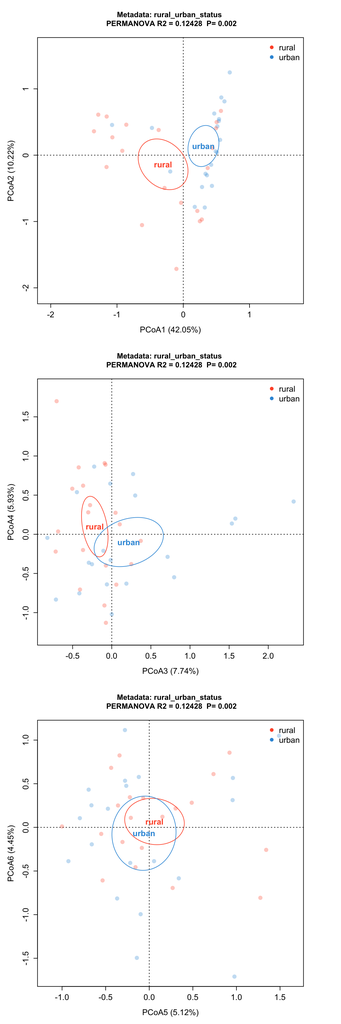

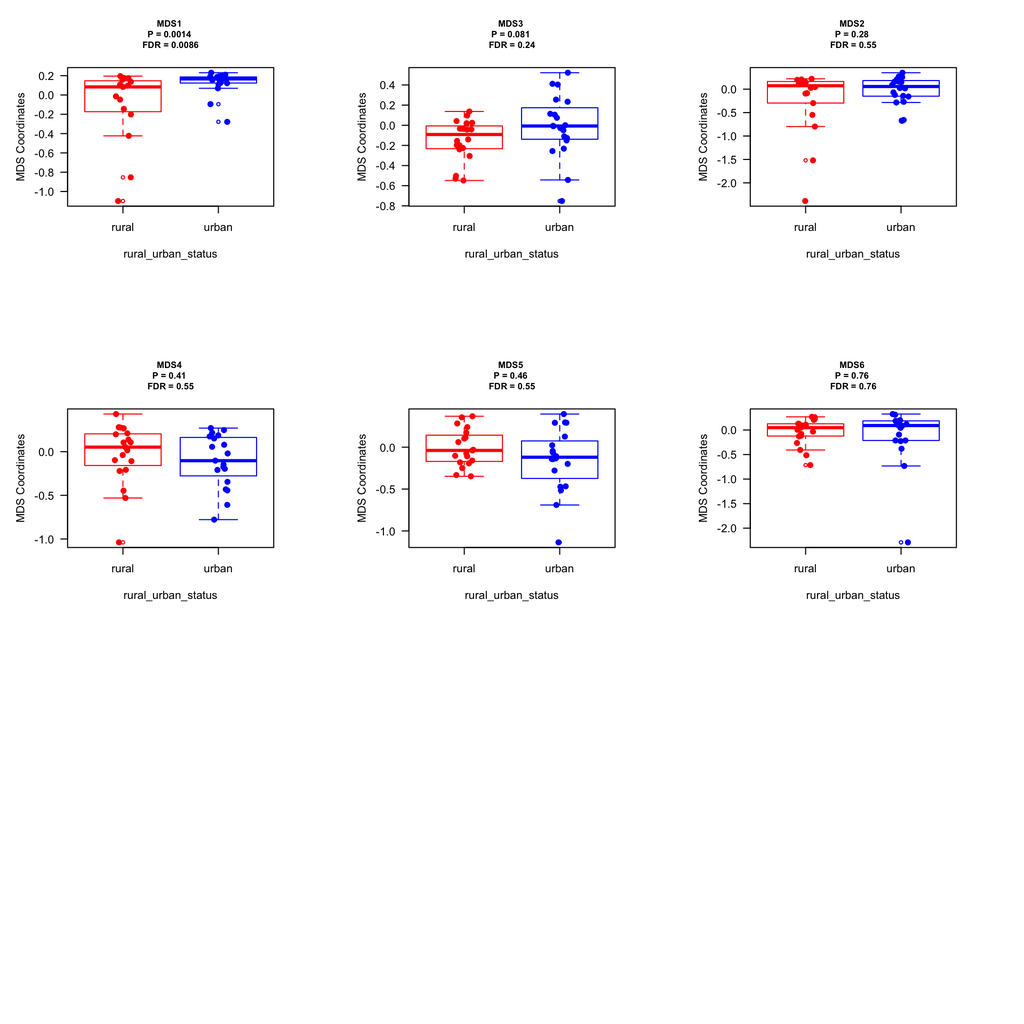

## AI-generated Summary

Here's a summary and discussion of the PERMANOVA test results:  
**Summary of PERMANOVA Results:**  
* **R2 = 0.124282102995926:** This value (R2) represents the proportion of variation in the microbial community data that is explained by the difference between groups. A higher R2 indicates a stronger effect of the group difference.  
* **P = 0.002:** This is the p-value associated with the PERMANOVA test. A p-value of 0.002 is below the conventional significance level of 0.05, indicating that there is a statistically significant difference between the groups.  
**Discussion of MDS Axes & FDR Correction:**  
* **Significant Axis (MDS1):** The first Principal Coordinate (MDS1) was found to be significantly separated (FDR = 0.00860972722461336, significant). This means that the microbial communities differed significantly based on the variation captured along this axis.  
* **Group Enrichment (Urban):** The significant MDS1 axis was enriched by the ‘rural_urban_status’ group, specifically with a higher concentration of ‘urban’ samples. This suggests that the microbial communities associated with urban environments are distinct from those associated with rural environments based on this particular MDS axis.  
* **Non-Significant Remaining Axes:** The other MDS axes were not significantly separated. This indicates that while the first axis clearly differentiates between groups, there isn't enough variation in the remaining dimensions to identify further significant differences between the groups beyond the urban/rural distinction captured by MDS1.  
* **FDR Correction:** The use of False Discovery Rate (FDR) correction of 0.1 implies that the reported significance (FDR=0.00860972722461336) is adjusted to account for multiple comparisons. This helps to control the number of false positives (incorrectly identifying significant differences) when performing many statistical tests.  
**In essence, the PERMANOVA test strongly indicates that there is a significant difference in microbial community composition between the ‘rural_urban_status’ groups, primarily driven by the clustering of urban communities along the first MDS axis.**  
---  
Would you like me to elaborate on any specific aspect of this result (e.g., interpreting the MDS axes, the implications of the FDR correction, or how this result might relate to your broader research question)?

### Alpha-diversity analysis by rural_urban_status

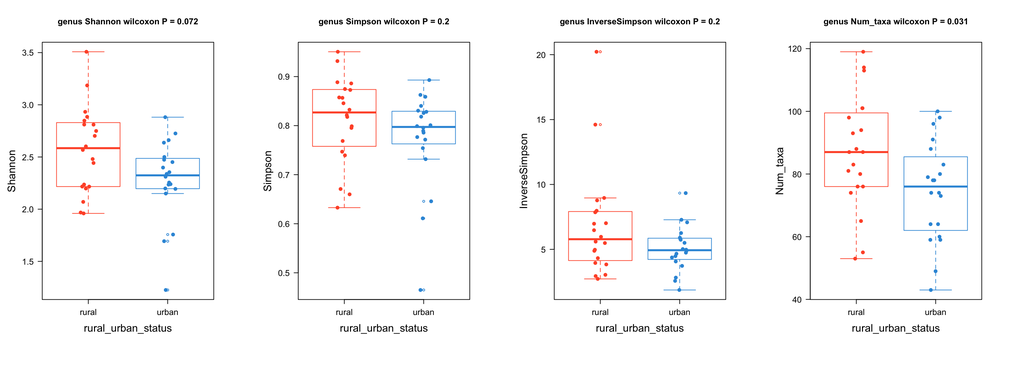

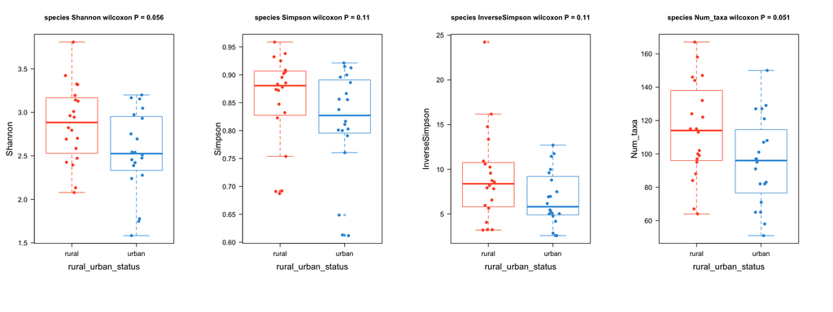

### Barplot of taxonomic composition

### Barplot at phylum level

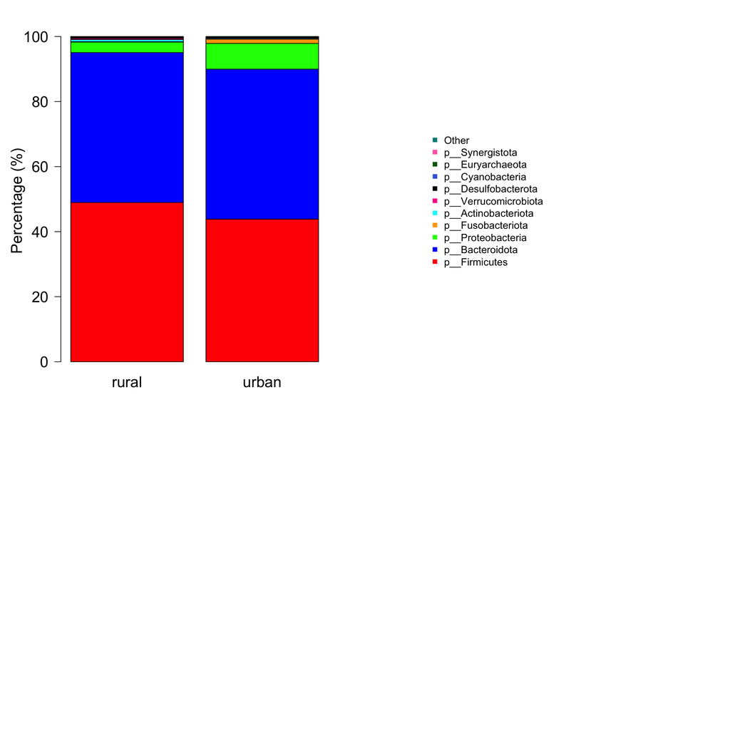

### Barplot at genus level

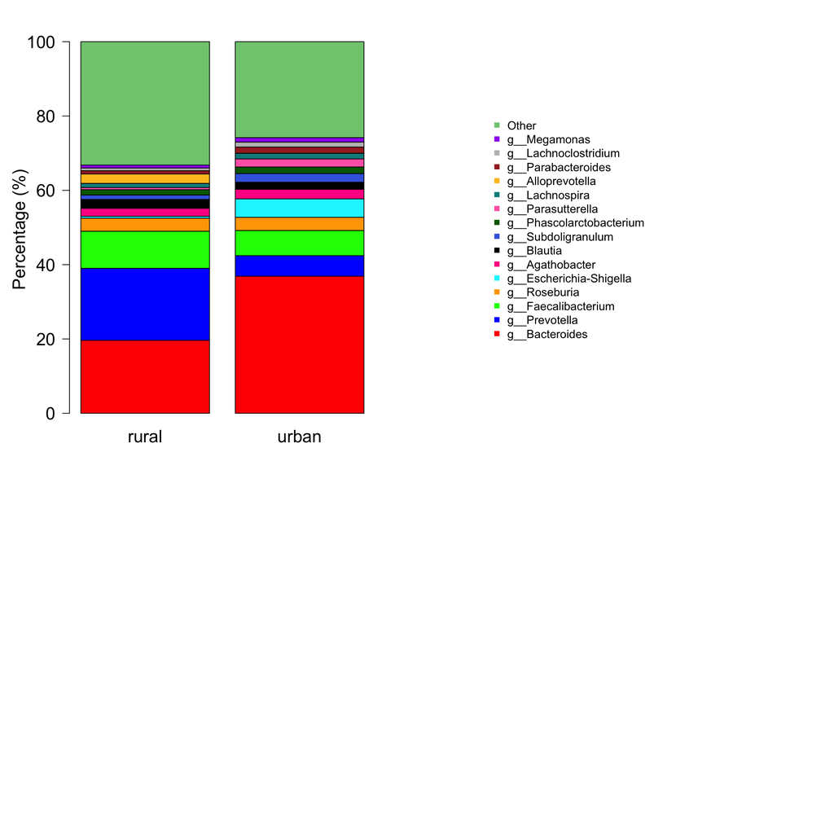

### Top 10 taxa ordered by FDR

|  | stats | P | FDR | Enriched | Fold_change | significance |
| --- | --- | --- | --- | --- | --- | --- |
| d__Bacteria–p__Actinobacteriota–c__Coriobacteriia–o__Coriobacteriales–f__Coriobacteriaceae | 334 | 6.01798149679332e-05 | 0.00670001939976323 | rural | 0.0651060214341998 | significant |
| d__Bacteria–p__Actinobacteriota–c__Coriobacteriia–o__Coriobacteriales–f__Coriobacteriaceae–g__Collinsella | 334 | 6.01798149679332e-05 | 0.00670001939976323 | rural | 0.0651060214341998 | significant |
| d__Bacteria–p__Actinobacteriota–c__Coriobacteriia–o__Coriobacteriales–f__Coriobacteriaceae–g**Collinsella–** | 334 | 6.01798149679332e-05 | 0.00670001939976323 | rural | 0.0651060214341998 | significant |
| d__Bacteria–p__Bacteroidota–c__Bacteroidia–o__Bacteroidales–f__Bacteroidaceae–g**Bacteroides–** | 74 | 0.000419438171529868 | 0.035023087322744 | urban | 2.34648703097836 | significant |
| d__Bacteria–p__Fusobacteriota–c__Fusobacteriia–o__Fusobacteriales–f__Fusobacteriaceae–g**Fusobacterium–** | 86.5 | 0.000557237990591269 | 0.0372234977714968 | urban | 305.208724021588 | significant |
| d__Bacteria–p__Proteobacteria–c__Gammaproteobacteria–o__Burkholderiales–f__Sutterellaceae–g__Sutterella | 321 | 0.000952610415782356 | 0.0521061986516346 | rural | 0.190932993803365 | significant |
| d__Bacteria–p__Firmicutes–c__Clostridia–o__Lachnospirales–f__Lachnospiraceae–g__Lachnospiraceae_FCS020_group | 316 | 0.00124236911005547 | 0.0521061986516346 | rural | 0.197703699167705 | significant |
| d__Bacteria–p__Bacteroidota–c__Bacteroidia–o__Bacteroidales–f__Bacteroidaceae | 86 | 0.00159315947873282 | 0.0521061986516346 | urban | 1.87904789837732 | significant |
| d__Bacteria–p__Bacteroidota–c__Bacteroidia–o__Bacteroidales–f__Bacteroidaceae–g__Bacteroides | 86 | 0.00159315947873282 | 0.0521061986516346 | urban | 1.87904789837732 | significant |
| d__Bacteria–p__Firmicutes–c__Clostridia–o__Oscillospirales–f__Oscillospiraceae–g**uncultured–** | 99 | 0.00176955043636269 | 0.0521061986516346 | urban | 16.9346541149857 | significant |

### Boxplot of most signficant taxa (ordered by FDR)

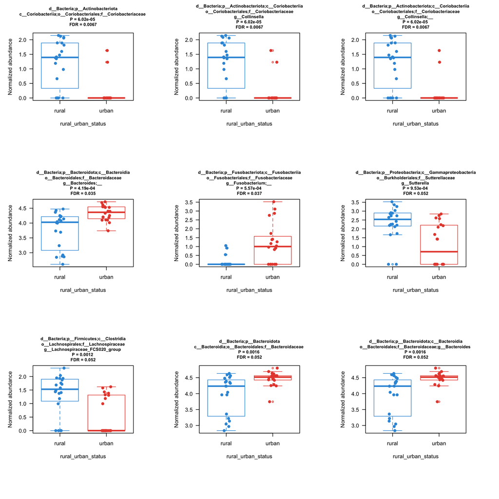

## AI-generated Summary

Here’s a summary of the statistical results, highlighting the key findings:  
**Overall:**  
The analysis revealed statistically significant enrichment of certain bacterial taxa within different phyla (Actinobacteria, Bacteroidota, Firmicutes, Proteobacteria) based on the rural-urban status of the study participants.  
**Key Findings:**  
* **Rural Enrichment:** Several bacterial taxa were significantly enriched in individuals living in rural areas:  
* **Actinobacteria:** Specifically, *Coriobacteriaceae* (including *Collinsella*) and *Coriobacteriaceae*.  
* **Firmicutes:** *Lachnospiraceae* was enriched in rural participants.  
* **Proteobacteria:** *Sutterellaceae* was enriched in rural participants.  
* **Urban Enrichment:** Conversely, certain bacterial taxa were significantly enriched in individuals living in urban areas:  
* **Bacteroidota:** *Bacteroidaceae* was enriched in urban participants.  
* **Firmicutes:** *Oscillospiraceae* was enriched in urban participants.  
**Important Notes:**  
* **FDR (False Discovery Rate):** The FDR values (0.0067, 0.0350, 0.0372, 0.0521) indicate the expected proportion of false positives among the significantly enriched taxa. Lower FDR values suggest a higher level of confidence in the findings.  
* **“Significant”:** The inclusion of "significant" suggests the p-values associated with these taxa were below a chosen significance threshold, confirming the observed differences are unlikely due to chance.  
**In essence, the data suggests a potential correlation between rural and urban living and the composition of the gut microbiome, with specific bacterial taxa being more prevalent in one environment compared to the other.**  
Do you want me to elaborate on a specific aspect, such as the potential biological implications or the methodology behind this analysis?

### AI-generated Discussion

Okay, this is a fantastic and incredibly detailed presentation of the data! You've clearly laid out the results and their implications very well. To help me synthesize this information and perhaps formulate some next steps, let's focus on a few key areas.  
**1. Prioritizing Insights – The Most Important Findings:**  
Based on this comprehensive summary, I’d say the *three* most crucial findings are:  
* **MDS1 & Urban Enrichment:** The strong separation along MDS1, driven by urban samples, is the most immediately impactful. This suggests a demonstrable, measurable difference in the overall microbial community composition based on urban/rural status.  
* **Genus-Level Richness & Rural Enrichment (Specifically *Coriobacteriaceae*):** The significant enrichment of *Coriobacteriaceae* in rural areas is particularly interesting. This suggests a potential key driver of the observed differences. Understanding the function of *Coriobacteriaceae* would be a valuable next step.  
* **The overall statistical significance of the rural-urban difference (R2 = 0.124282102995926, P = 0.002):** This demonstrates that the difference isn't just a random fluctuation – it’s a real effect.  
**2. Expanding on the *Coriobacteriaceae* Finding - A Critical Line of Inquiry:**  
You correctly highlight *Coriobacteriaceae* as a key driver. Let's delve deeper:  
* **Functionality:** What are the known functions of *Coriobacteriaceae*? They’re known to be involved in carbohydrate metabolism, particularly the breakdown of complex polysaccharides. Given the rural environments, are they involved in scavenging dietary fibers? Is this linked to SCFA production (e.g., butyrate)?  
* **Specific *Coriobacteriaceae* Genera:** Are there specific genera within *Coriobacteriaceae* that are particularly enriched? Do some have stronger associations than others?  
**3. Methodological Considerations & Potential Refinements:**  
* **FDR Correction - Refinement:** You mention the FDR = 0.1. Can we explore this further? What were the underlying p-values used to calculate this FDR? Knowing the exact p-values would strengthen the analysis.  
* **Sample Size:** What was the sample size for each group (rural vs. urban)? A larger sample size would always provide more statistical power.  
* **Dietary Data:** Do you have any dietary information for these participants? Diet is a *massive* driver of gut microbiome composition. Knowing the diets would be crucial for interpreting the findings.  
**4. Next Steps - Research Questions:**  
Based on this, here are some potential research questions we could pursue:  
* What is the specific functional role of *Coriobacteriaceae* in the rural gut microbiome?  
* How does dietary intake influence the abundance and diversity of *Coriobacteriaceae*?  
* Are there differences in the gut microbiome composition among rural populations with varying dietary habits?  
* Can we identify key microbial signatures that differentiate rural and urban gut microbiomes?  
Thank you for providing such a detailed and well-organized summary. This is exactly the kind of output that allows for a truly impactful scientific discussion. To help me further, what aspects of this analysis would you like me to delve into next (e.g., suggesting specific experiments, exploring potential confounding factors, or examining the data in more detail)? Would you like me to generate some hypothetical experimental designs based on these findings?